# Stock Market Data Analysis

This notebook connects to BigQuery and visualizes the stock market data that we've transformed using dbt. We'll create several visualizations to analyze trends and patterns in the data.

## Setup and Configuration

First, let's install and import the necessary libraries.

## Connect to BigQuery

Now, let's set up the connection to BigQuery. Make sure you have the service account key file available.

## Query and Visualize Monthly Performance Data

Let's start by querying the monthly performance data from our mart model.

|  | month | avg_sp500_price | avg_nasdaq_price | avg_tech_price | avg_commodity_price | avg_crypto_price |
| --- | --- | --- | --- | --- | --- | --- |
| 0 | 2019-02-01 | 2757.549444 | 7029.136667 | 108.600625 | 541.109632 | 1911.561667 |
| 1 | 2019-03-01 | 2803.983810 | 7254.175238 | 111.686667 | 540.662643 | 2032.051190 |
| 2 | 2019-04-01 | 2903.800000 | 7660.580952 | 117.382083 | 549.980679 | 2646.316429 |
| 3 | 2019-05-01 | 2854.705909 | 7480.984545 | 115.695568 | 534.629045 | 3735.768636 |
| 4 | 2019-06-01 | 2890.166000 | 7505.149000 | 114.571812 | 548.609025 | 4816.613500 |

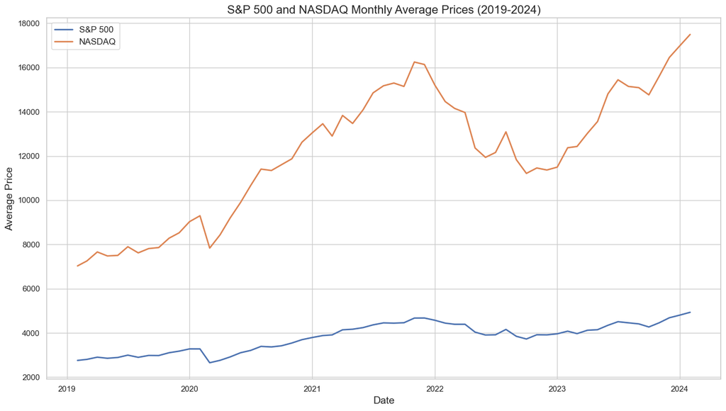

## Analyze Tech Stock Performance

Let's query and analyze the performance of major tech stocks.

|  | month | avg_apple_price | avg_microsoft_price | avg_google_price | avg_amazon_price | avg_meta_price | avg_nvidia_price | avg_tesla_price |
| --- | --- | --- | --- | --- | --- | --- | --- | --- |
| 0 | 2019-02-01 | 43.004444 | 108.213889 | 56.078889 | 81.348889 | 164.763889 | 38.411667 | 20.500000 |
| 1 | 2019-03-01 | 45.823810 | 115.133810 | 59.216190 | 86.124762 | 167.411429 | 41.830952 | 18.516667 |
| 2 | 2019-04-01 | 50.130000 | 122.794762 | 61.572381 | 93.309048 | 180.544286 | 46.784286 | 17.776190 |
| 3 | 2019-05-01 | 47.819091 | 126.346364 | 57.773182 | 93.469091 | 186.082273 | 39.990455 | 14.646818 |
| 4 | 2019-06-01 | 48.243500 | 131.994000 | 54.151000 | 92.630000 | 181.274500 | 37.417500 | 14.248000 |

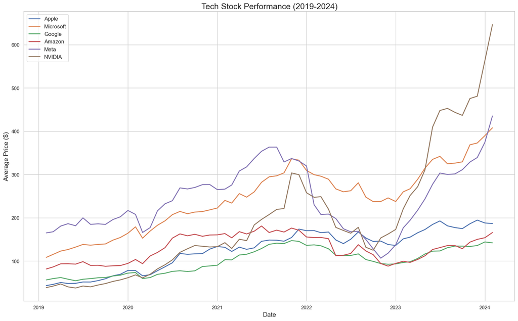

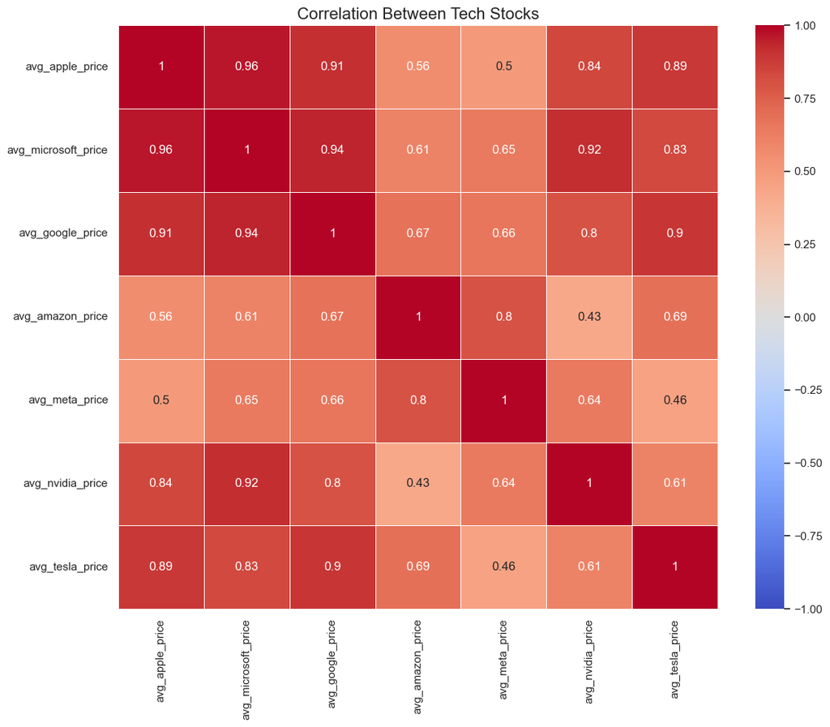

## Analyze Commodity and Cryptocurrency Performance

Now, let's look at commodities and cryptocurrencies.

|  | month | avg_gold_price | avg_crude_oil_price | avg_natural_gas_price | avg_bitcoin_price | avg_ethereum_price |
| --- | --- | --- | --- | --- | --- | --- |
| 0 | 2019-02-01 | 1322.844444 | 54.965000 | 2.679722 | 3696.177778 | 126.945556 |
| 1 | 2019-03-01 | 1300.571429 | 58.168095 | 2.804667 | 3928.285714 | 135.816667 |
| 2 | 2019-04-01 | 1289.266667 | 63.870952 | 2.603095 | 5128.438095 | 164.194762 |
| 3 | 2019-05-01 | 1285.318182 | 60.865455 | 2.592409 | 7252.340909 | 219.196364 |
| 4 | 2019-06-01 | 1364.095000 | 54.706500 | 2.330350 | 9360.580000 | 272.647000 |

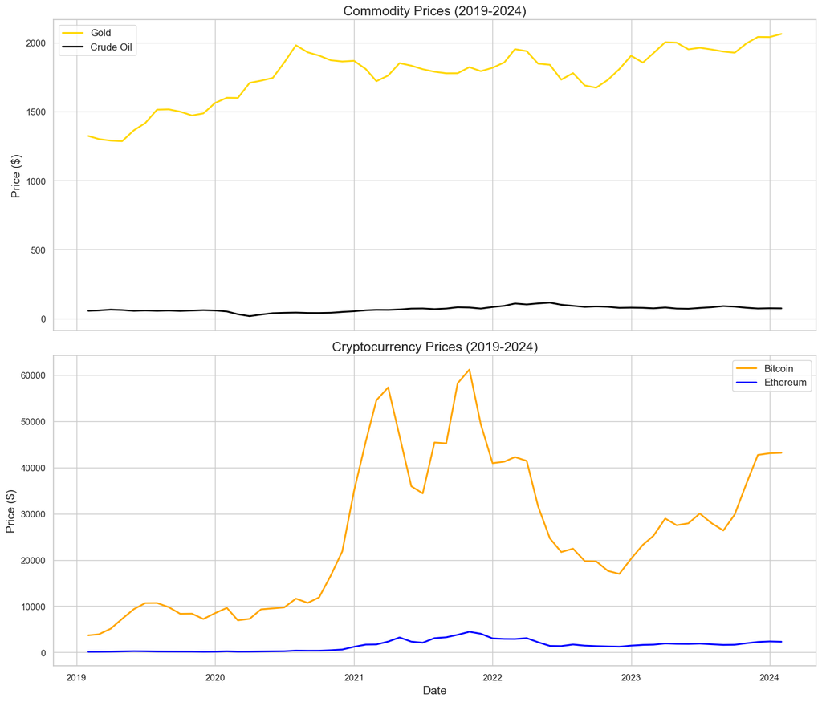

## Analyze Relationships Between Different Asset Classes

Let's explore the relationships between different asset classes.

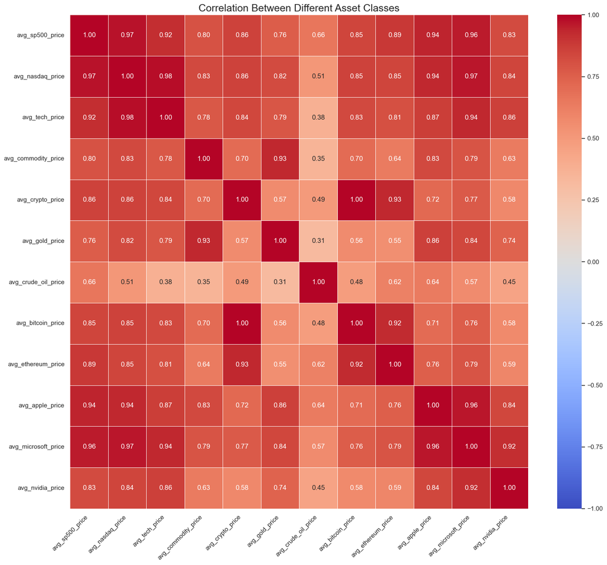

## Analyze Performance During Key Market Events

Let's identify and analyze performance during key market events like the COVID-19 pandemic.

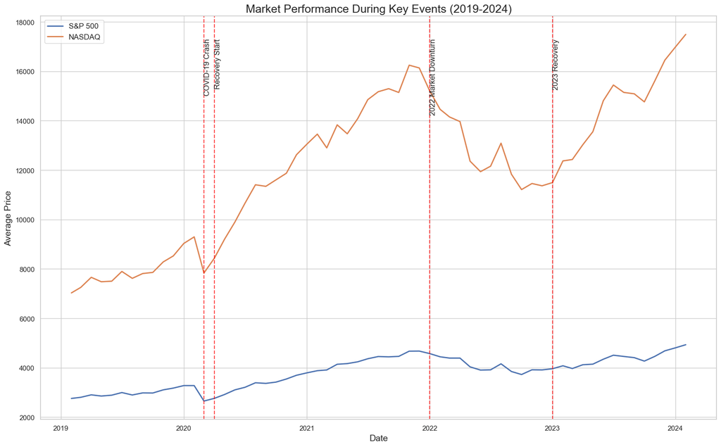

```
Monthly Returns:

Performance Metrics:
```

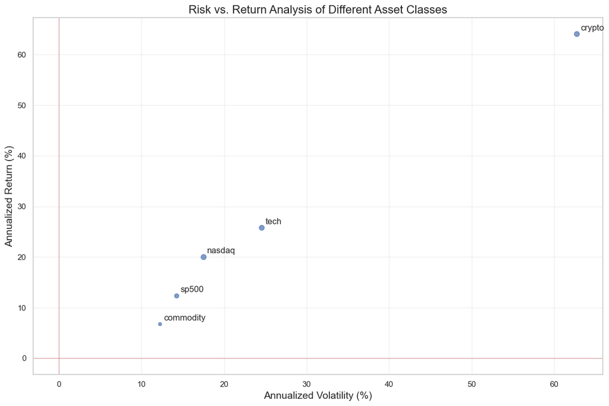

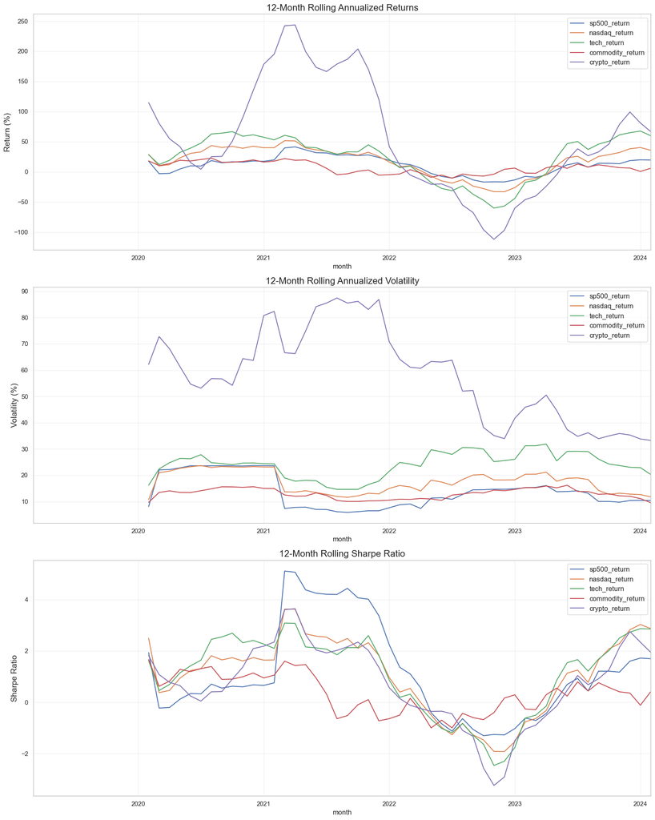

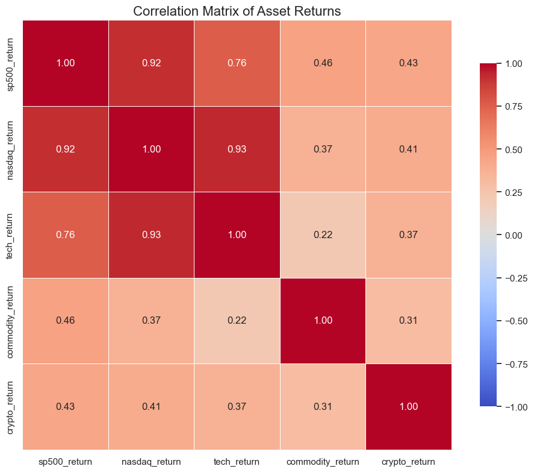

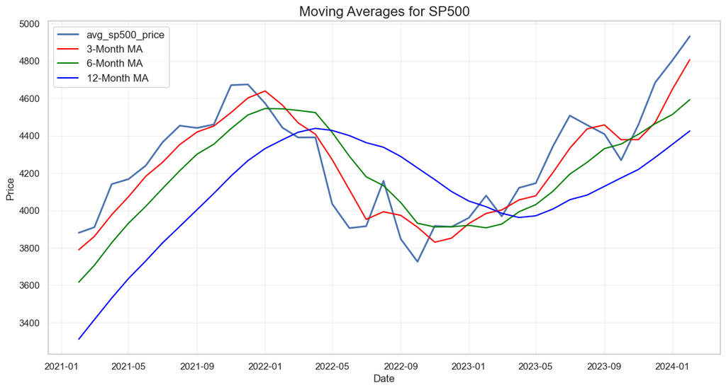

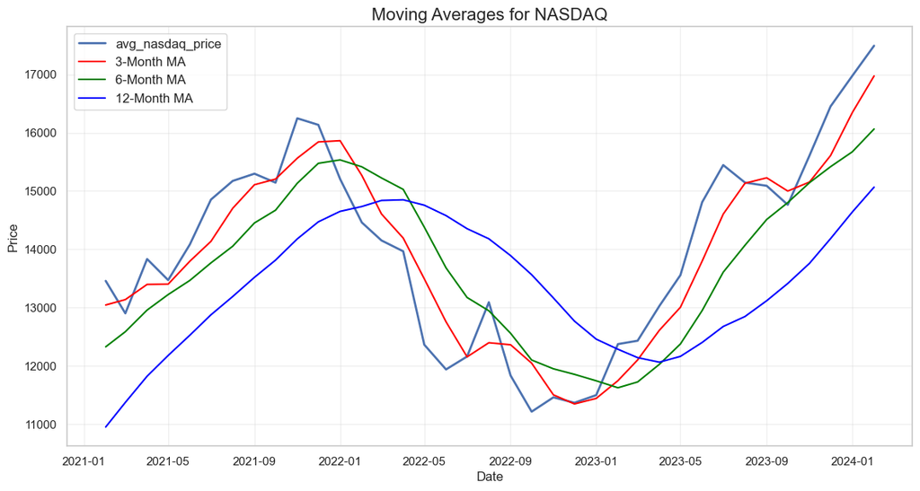

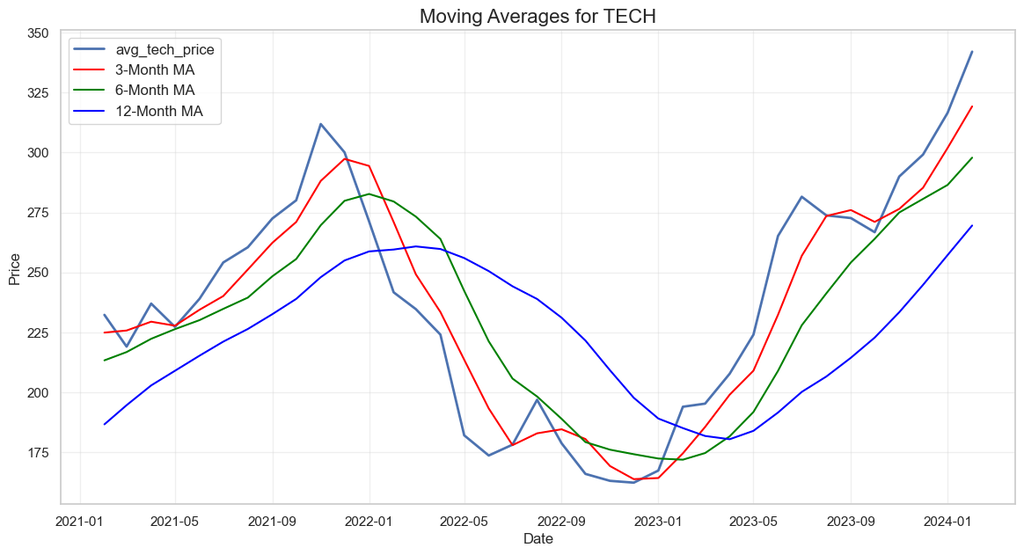

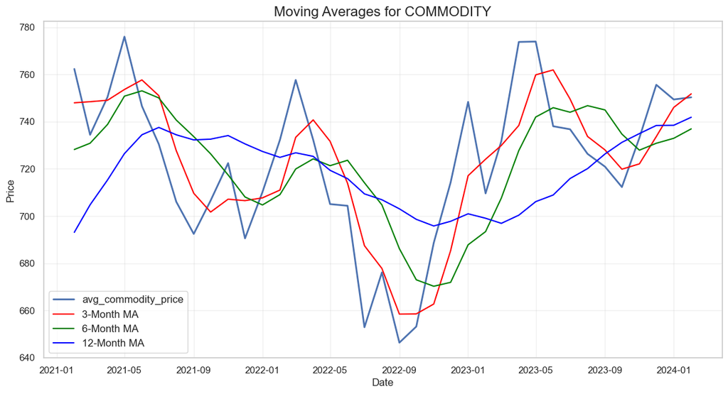

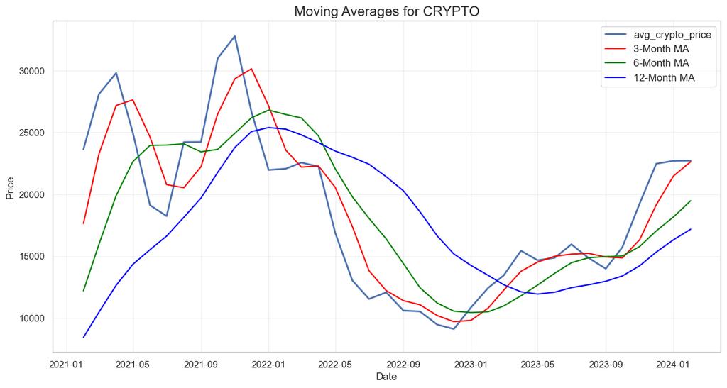

```
Recent Market Trends (1: Bullish, -1: Bearish, 0: Neutral):
```

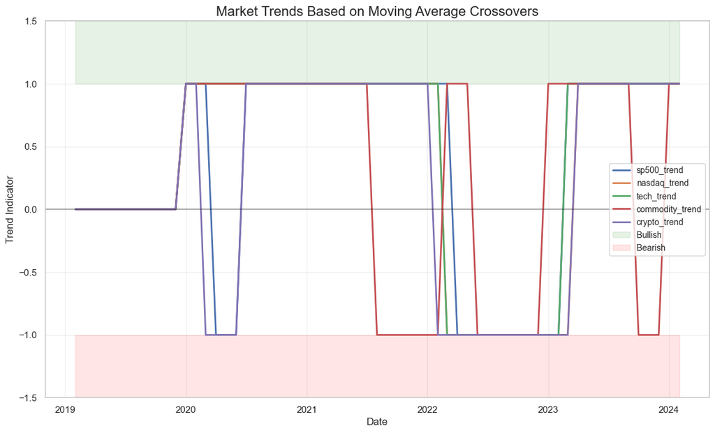

```
Recent Momentum (% change):
```

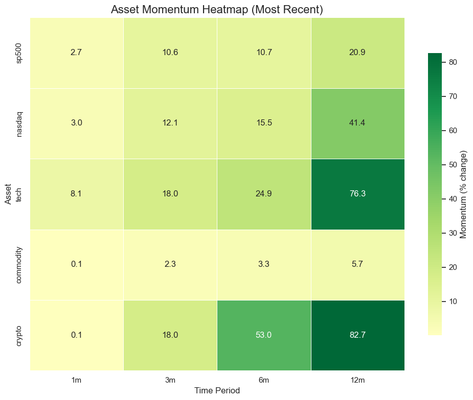

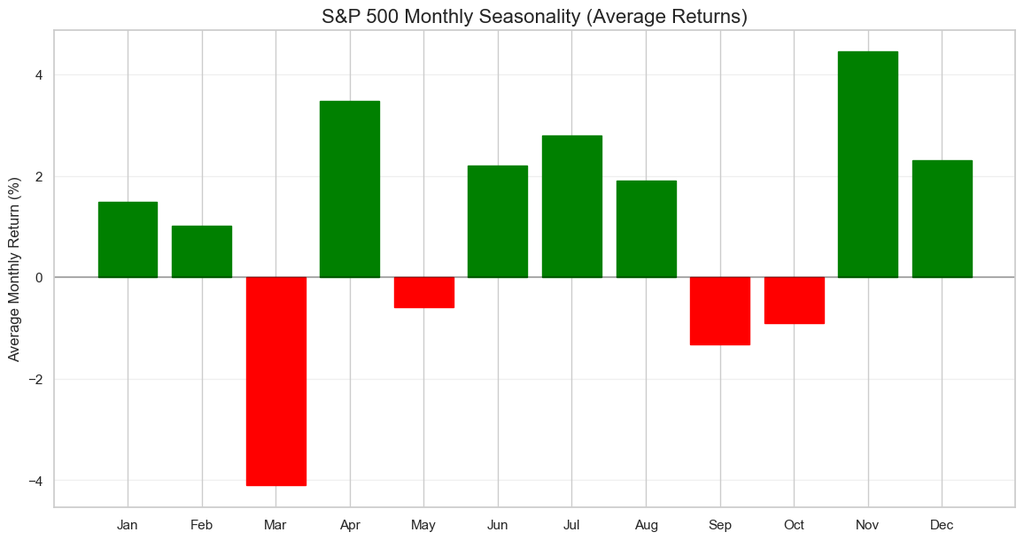

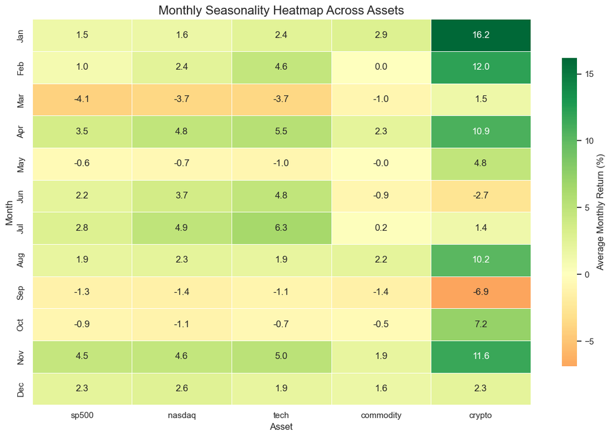

[output not shown]

```
Starting portfolio optimization with BigQuery data...

Asset Price Data:
```

| month | avg_sp500_price | avg_nasdaq_price | avg_tech_price | avg_commodity_price | avg_crypto_price |
| --- | --- | --- | --- | --- | --- |
| 2019-02-01 | 2757.549444 | 7029.136667 | 108.600625 | 541.109632 | 1911.561667 |
| 2019-03-01 | 2803.983810 | 7254.175238 | 111.686667 | 540.662643 | 2032.051190 |
| 2019-04-01 | 2903.800000 | 7660.580952 | 117.382083 | 549.980679 | 2646.316429 |
| 2019-05-01 | 2854.705909 | 7480.984545 | 115.695568 | 534.629045 | 3735.768636 |
| 2019-06-01 | 2890.166000 | 7505.149000 | 114.571812 | 548.609025 | 4816.613500 |

```
Monthly Returns:
```

| month | sp500 | nasdaq | tech | commodity | crypto |
| --- | --- | --- | --- | --- | --- |
| 2019-03-01 | 0.016839 | 0.032015 | 0.028416 | -0.000826 | 0.063032 |
| 2019-04-01 | 0.035598 | 0.056024 | 0.050995 | 0.017234 | 0.302288 |
| 2019-05-01 | -0.016907 | -0.023444 | -0.014368 | -0.027913 | 0.411686 |
| 2019-06-01 | 0.012422 | 0.003230 | -0.009713 | 0.026149 | 0.289323 |
| 2019-07-01 | 0.036658 | 0.052321 | 0.040704 | 0.040410 | 0.132917 |

```
Annualized Statistics:
```

|  | Annualized Return (%) | Annualized Volatility (%) |
| --- | --- | --- |
| sp500 | 12.743938 | 14.259971 |
| nasdaq | 19.918133 | 17.523531 |
| tech | 26.150369 | 24.568174 |
| commodity | 7.293826 | 12.243999 |
| crypto | 68.427129 | 62.745922 |

```
Finding optimal portfolios...

Maximum Sharpe Ratio Portfolio:
Expected Annual Return: 33.50%
Expected Annual Volatility: 25.28%
Sharpe Ratio: 1.25
```

|  | Asset | Allocation (%) |
| --- | --- | --- |
| 1 | nasdaq | 51.92 |
| 4 | crypto | 25.03 |
| 2 | tech | 23.05 |
| 0 | sp500 | 0.00 |
| 3 | commodity | 0.00 |

```
Minimum Variance Portfolio:
Expected Annual Return: 9.27%
Expected Annual Volatility: 11.16%
Sharpe Ratio: 0.65
```

|  | Asset | Allocation (%) |
| --- | --- | --- |
| 3 | commodity | 63.81 |
| 0 | sp500 | 36.19 |
| 1 | nasdaq | 0.00 |
| 2 | tech | 0.00 |
| 4 | crypto | 0.00 |

```
Equal Weight Portfolio:
Expected Annual Return: 26.91%
Expected Annual Volatility: 20.72%
Sharpe Ratio: 1.20
```

|  | Asset | Allocation (%) |
| --- | --- | --- |
| 0 | sp500 | 20.0 |
| 1 | nasdaq | 20.0 |
| 2 | tech | 20.0 |
| 3 | commodity | 20.0 |
| 4 | crypto | 20.0 |

```
Calculating efficient frontier...
```

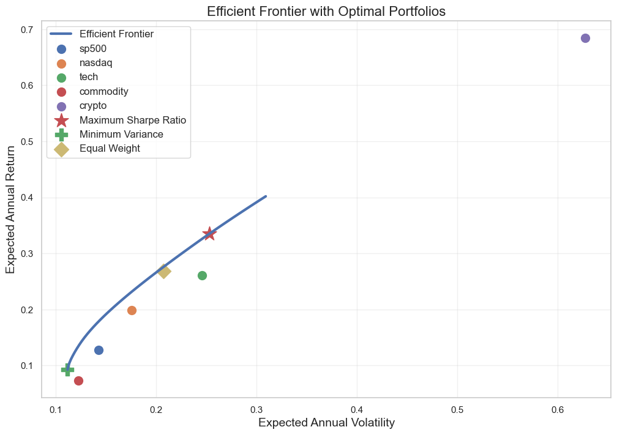

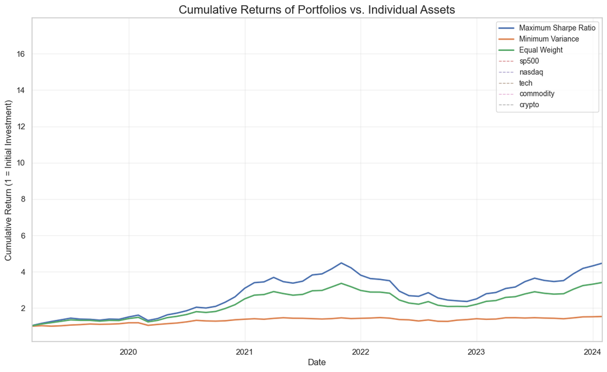

```
Portfolio Optimization Complete!
```

## Conclusion

In this notebook, we've created various visualizations to analyze the stock market data from 2019-2024. We've looked at:

1. Performance of major indices (S&P 500, NASDAQ)
2. Tech stock performance and correlations
3. Commodity and cryptocurrency trends
4. Relationships between different asset classes
5. Performance during key market events

These visualizations provide insights into market trends and can help inform investment decisions.